# Digit Recognizer KNN

reference: https://api.rpubs.com/dardodel/digit_recognition_KNN_NN_SVM

```r
library(readr)
train <- read_csv("./input/train.csv")
test <- read_csv("./input/test.csv")
```

what is the size of each data set?

```r
dim(train) ; dim(test)
```

```
[1] 42000   785
[1] 28000   784
```

Train data set has one extra column, called “label”, containing the “digit” that is represented by the other 784 columns. The 784 (28x28 cells) columns contain a value from 0 to 255. This value tells us the lightness or darkness of each cell. Let’s convert the “label” column to factor:

```r
train[, 1] <- as.factor(train[, 1]$label)  # As Category
```

All the other columns are numeric:

```r
head(sapply(train[1,], class))
```

```
    label    pixel0    pixel1    pixel2    pixel3    pixel4
 "factor" "numeric" "numeric" "numeric" "numeric" "numeric"
```

For more information about the data see the data description on Kaggle. There are 42000 observation with 784 features. However, some columns contain zero for all observations or they have near zero variance. These columns need to be removed:

```r
train_orig <- train
test_orig <- test
library(caret)
nzv.data <- nearZeroVar(train, saveMetrics = TRUE)
drop.cols <- rownames(nzv.data)[nzv.data$nzv == TRUE]
train <- train[,!names(train) %in% drop.cols]
test <- test[,!names(test) %in% drop.cols]
```

# Exploratory data analysis

Now, let’s do some exploratory data analysis. Using data visualization and EDA:

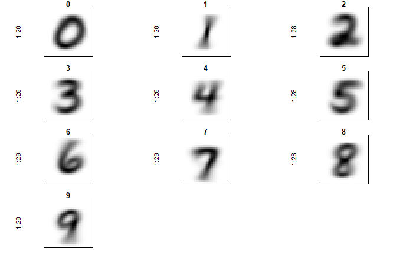

```r
library(RColorBrewer)
BNW <- c("white", "black")
CUSTOM_BNW <- colorRampPalette(colors = BNW)

par(mfrow = c(4, 3), pty = "s", mar = c(1, 1, 1, 1), xaxt = "n", yaxt = "n")

images_digits_0_9 <- array(dim = c(10, 28 * 28))

for (digit in 0:9) {
  images_digits_0_9[digit + 1, ] <- apply(train_orig[train_orig[, 1] == digit, -1], 2, sum)
  images_digits_0_9[digit + 1, ] <- images_digits_0_9[digit + 1, ]/max(images_digits_0_9[digit + 1, ]) * 255
  z <- array(images_digits_0_9[digit + 1, ], dim = c(28, 28))
  z <- z[, 28:1]
  image(1:28, 1:28, z, main = digit, col = CUSTOM_BNW(256))
}
```

More blurriness, more chance of misprediction. For example, 0 has a smooth and fully dark line but see how blurry is 9 or 4 or even 1. That means there is a higher chance of incorrect prediction of such numbers. We will explore this more in detail when we predict our validation data set. What is the proportion of each digit in the train set?

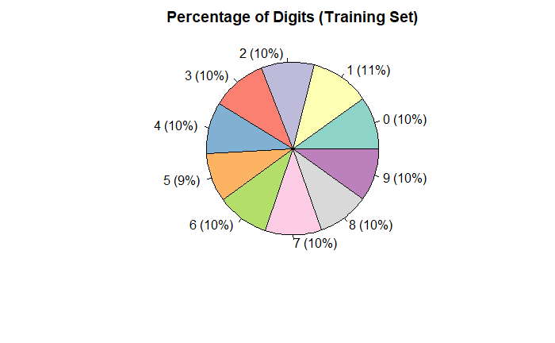

```r
CUSTOM_BNW_PLOT <- colorRampPalette(brewer.pal(10, "Set3"))
LabTable <- table(train_orig$label)
par(mfrow = c(1, 1))
percentage <- round(LabTable/sum(LabTable) * 100)
labels <- paste0(row.names(LabTable), " (", percentage, "%) ")
pie(LabTable, labels = labels, col = CUSTOM_BNW_PLOT(10), main = "Percentage of Digits (Training Set)")
```

```r
set.seed(43210)
trainIndex <- createDataPartition(train$label, p = 0.1, list = FALSE, times = 1)
allindices <- c(1:42000)
training <- train[trainIndex,]
validating <- train[-trainIndex,]
vali0_index <- allindices[! allindices %in% trainIndex]
validIndex <- createDataPartition(validating$label, p = 0.11, list = FALSE, times = 1)
validating <- validating[validIndex,]
original_validindex <- vali0_index[validIndex]
```

```r
Contrast <- function (DATASET, POWER) {
  outDATASET <- cbind(DATASET$label, as.data.frame((DATASET[,-1]/255)^(POWER)*255))
  names(outDATASET)[1] <- "label"
  outDATASET
}
```

#MODEL: KNN

The K-Nearest Neighbor (KNN) is a simple yet accurate algorithm to solve the Digit Recognition problem. For predicting a new instance, KNN calculates the Euclidean Distance between the new instance and all the instances in the entire training set. Then, the algorithm looks for the top K nearest (most similar) instances and outputs the class with the highest frequency (most vote) as prediction. The question is how to choose K? Cross Validation can be used to choose the best value for K that results in the highest accuracy. I use CARET package to train KNN and choose K. Then, I will switch to FNN which is much faster.

to install doMC on Windows, R version 4.0.2: type in the Console install.packages(“doMC”, repos=“http://R-Forge.R-project.org”)

```r
power = 3
training2   <- Contrast(training, 1/power)
training3   <- Contrast(training,   power)
validating2 <- Contrast(validating, 1/power)
validating3 <- Contrast(validating, power)
training4 <- rbind(training, training2, training3)
```

```r
library(doMC)
registerDoMC(cores = 3)
ctrl <- trainControl(method="repeatedcv",repeats = 1, number = 4, verboseIter = T, allowParallel = T)
knnFit <- train(label ~ ., data = training, method = "knn", trControl = ctrl)
```

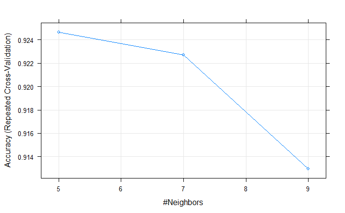

```r
plot(knnFit)
```

So, we choose K=5. At first, FNN will be trained with three training sets: 1) original “training” 2) “training2” (lower contrast) 3) “training3” (higher contrast). See the FNN documentation for different “algorithm” options and other settings. I found that “kd-tree” was the best choice.

```r
library(FNN)
fnn.kd1 <- FNN::knn(training[,-1], validating[,-1], training$label, k=5, algorithm = c("kd_tree"))
fnn.kd.pred1 <- as.numeric(fnn.kd1)-1

fnn.kd2 <- FNN::knn(training2[,-1], validating2[,-1], training2$label, k=5, algorithm = c("kd_tree"))
fnn.kd.pred2 <- as.numeric(fnn.kd2)-1

fnn.kd3 <- FNN::knn(training3[,-1], validating3[,-1], training3$label, k=5, algorithm = c("kd_tree"))
fnn.kd.pred3 <- as.numeric(fnn.kd3)-1

fnn.kd4 <- FNN::knn(training4[,-1], validating2[,-1], training4$label, k=5, algorithm = c("kd_tree"))
fnn.kd.pred4 <- as.numeric(fnn.kd4)-1
```

```r
table(fnn.kd.pred1)
```

```
fnn.kd.pred1
  0   1   2   3   4   5   6   7   8   9
427 523 377 449 389 364 423 459 343 408
```

```r
table(validating$label)
```

```
  0   1   2   3   4   5   6   7   8   9
409 464 414 431 404 376 410 436 403 415
```

```r
confusionMatrix(
  factor(fnn.kd.pred1, levels = 1:400),
  factor(validating$label, levels = 1:400)
)
```

[output not shown]

[output cut: 87 more lines]

[output not shown]

```r
confusionMatrix(
  factor(fnn.kd.pred2, levels = 1:400),
  factor(validating2$label, levels = 1:400)
)
```

[output not shown]

```r
confusionMatrix(
  factor(fnn.kd.pred3, levels = 1:400),
  factor(validating3$label, levels = 1:400)
)
```

[output not shown]

```r
confusionMatrix(
  factor(fnn.kd.pred4, levels = 1:350),
  factor(validating2$label, levels = 1:350)
)
```

[output not shown]